# Quick Start Guide

Wenchuan Guo and Bob Zhong

2020-05-09

This guide introduces the basic usage of `tsdf`. For more details, see the documentation for individual functions.

## Installation

Type the following command in R console :

```r
install.packages("tsdf")
```

or install the latest version from GitHub

```r
#check if devtools is installed
if(!"devtools" %in% rownames(installed.packages())){
    install.packages(devtools)
}
devtools::install_github("wguo1990/tsdf")
```

Then the R package will be downloaded and installed to the default directories. Run the following command to load the package :

```r
library(tsdf)
```

We will briefly go over main functions and their basic usage in the following sections.

## Zhong’s 2-/3-stage Phase II designs

```r
# type I errors
alpha1 <- 0.15
alpha2 <- 0.10
# type II error
beta <- 0.15
# response rate
pc <- 0.25
# alternative
pt <- pc + 0.20
# 2-stage design
out <- opt.design(alpha1, alpha2, beta, pc, pt, stage = 2)
```

`out` is an object of class `opt.design`. S3 method `print` is available for `opt.design` class. To extract information, run

```r
print(out)
```

[output not shown]

Alpha-spending method is added to two-/three-stage designs. `opt.design` supports Hwang-Shih-DeCani spending function where `sf.param` specifies the parameter. For two-stage design, the default value is set to be `NULL` which means alpha-spending is not used. For three-stage design, the default is 4. User can change this parameter to set the alpha spent at first 1 or 2 stage. For example, to use a Pocock-like spending function, let `sf.param = 1`, then run

```r
opt.design(alpha1, alpha2, beta, pc, pt, stage = 2, sf.param = 1)
```

## Decision table for Phase I dose-finding

`dec.table` function is used to generate decision table for a three-stage dose-finding design. `alpha.l` (left side), `alpha.r` (right side), `alpha.u` (right side type I error for “DU”, usually less than `alpha.r`) are three type I errors control the boundary of decisions. `pt` is the target toxicity level. `pt` is either a single or an interval value. This is also a group sequential design, so alpha-spending method is added. The `sf.param` option is same as in `opt.design`. The default value is set to be 4. We call `dec.table` function as follows

```r
# sample size
n <- rep(3, 3)
# type I errors
alpha.l <- 0.6
alpha.r <- 0.4
alpha.u <- 0.2
# target toxicity
pt <- 0.3
# call dec.table
out <- dec.table(alpha.l, alpha.r, alpha.u, pt, n)
```

`out` is an object of class `dec.table` that contains all the relevant information including decision table, real type errors and input parameter. However, we do not recommend users to extract the components from this object directly. `plot` and `print` S3 method are available for `dec.table` class.

We can view the decision table using `print` function :

```r
print(out)
```

```
##   3  6  9
## 0 E  E  E
## 1 S  E  E
## 2 D  S  E
## 3 DU D  S
## 4 0  DU D
## 5 0  DU DU
## 6 0  DU DU
## 7 0  0  DU
## 8 0  0  DU
## 9 0  0  DU
##
##    Row : Number of DLTs
## Column : Number of subjects
##      E : Escalate to the next higher dose
##      S : Stay at the same dose
##      D : De-escalate to the previous lower dose
##     DU : De-escalate and never use this dose again
##
## Type 1 error :
##   alpha11   alpha12   alpha13   alpha21   alpha22   alpha23
## 0.3430000 0.4942630 0.5609700 0.2160000 0.3112560 0.3532639
## Type 2 error :  0.1690468
## Right-side type 1 error :
##   alpha11   alpha12   alpha13
## 0.0270000 0.0797310 0.1264898
```

or visualize the decision table by executing the `plot` function :

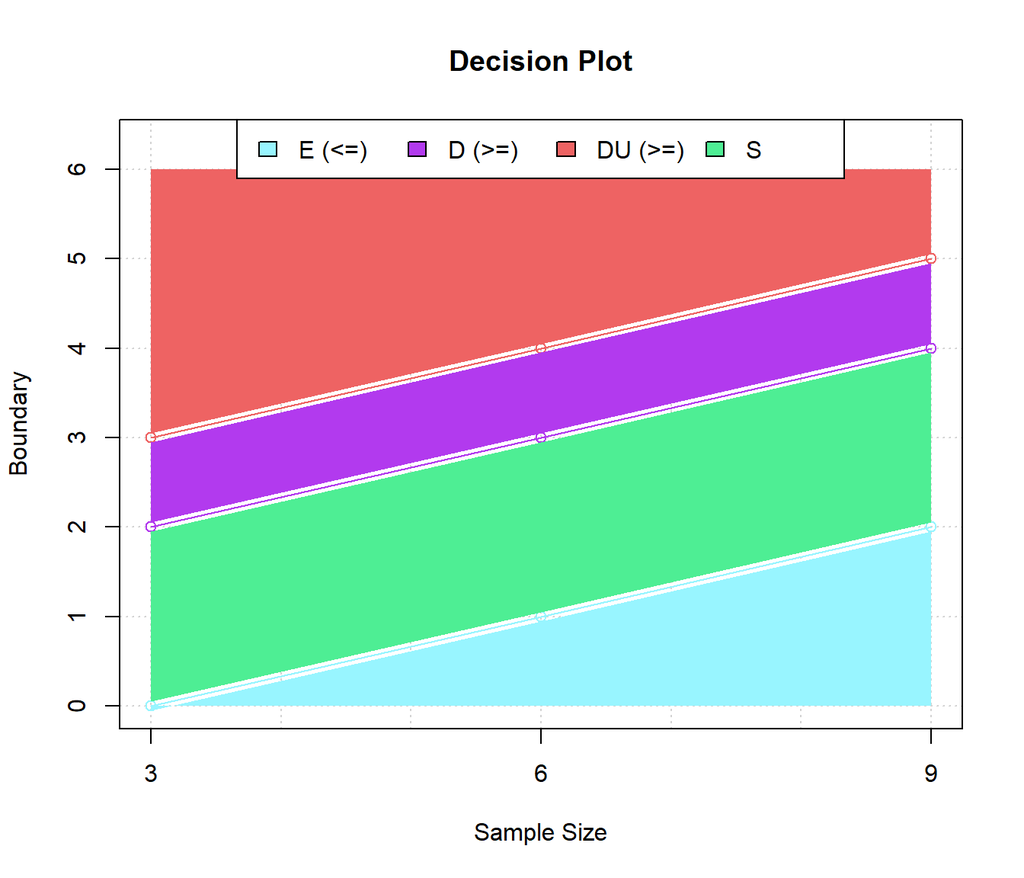

```r
plot(out)
```

## Dose-finding simulations

There are two functions that allow users to run dose-finding simulations using a user supplied decision table: `dec.sim` and `sl.sim`. To run simulations, users need to provide a decision table either from `dec.table` function or a user-supplied table (see details in next section), true probability of toxicity at each dose level, starting dose (default to lowest dose level) and number of simulated trials (default to 1000).

`dec.sim` runs one scenario simulation which is usually used for an initial test and `sl.sim` runs a list of scenarios from `.csv` or `.txt` files (See next section Data Format for details). Let’s see an example :

```r
# true toxicity
truep <- c(0.3, 0.45, 0.5, 0.6)
# generate a decision table
dt <- dec.table(0.6,0.4,0.2,0.3,c(3,3,3))
# run simulation
out1 <- dec.sim(truep, dt$table, start.level = 2, nsim = 1000)
```

The following command loads a sample scenarios list in `tsdf` package :

```r
test.file <- system.file("extdata", "testS.csv", package = "tsdf")
```

Run simulations using `sl.sim` :

```r
out2 <- sl.sim(dt$table, test.file)
```

```r
# target toxicity
pt <- c(0.3, 0.4)
summary(out2, pt)
```

```
## What does each column represent ?
##
## Level : Dose level
## Truth : True toxicity probability
## MTD   : The probability of selecting current dose level as the MTD
## Over  : The probability of selecting current dose level as over the MTD
## DLT   : The average number of subjects experienced DLT at current dose level
## NP    : The average number of subjects treated at current dose level
##
## Scenario  1
##
## Simulation results are based on 1000 simulated trials
## Starting dose level is 1 ; MTD is dose 1
## Target toxicity probability = 0.3
## Average number of subjects = 10.557
## Probability of selecting the true MTD = 0.478
## Probability of subjects treated at or below the true MTD = 0.627451
##
##   Level Truth   MTD  Over   DLT    NP
## 1     1  0.30 0.478 0.375 1.998 6.624
## 2     2  0.45 0.121 0.853 1.416 3.081
## 3     3  0.50 0.024 0.974 0.367 0.726
## 4     4  0.60 0.000 1.000 0.073 0.126
##
## Scenario  2
##
## Simulation results are based on 2000 simulated trials
## Starting dose level is 2 ; MTD is dose 3
## Target toxicity probability = 0.4
## Average number of subjects = 15.5385
## Probability of selecting the true MTD = 0.672
## Probability of subjects treated at or below the true MTD = 0.8201564
##
##   Level Truth    MTD   Over    DLT     NP
## 1     1  0.01 0.0395 0.0000 0.0025 0.3405
## 2     2  0.10 0.2550 0.0395 0.5040 5.0580
## 3     3  0.25 0.6720 0.2945 1.8155 7.3455
## 4     4  0.65 0.0315 0.9665 1.7060 2.6580
## 5     5  0.70 0.0000 1.0000 0.0945 0.1365
```

There are four different type of plots for `dec.sim` object where option `s` indicates the number of scenario you want to plot and `pt` is the target toxicity for each scenario, see more details in `plot.dec.sim` R documentation:

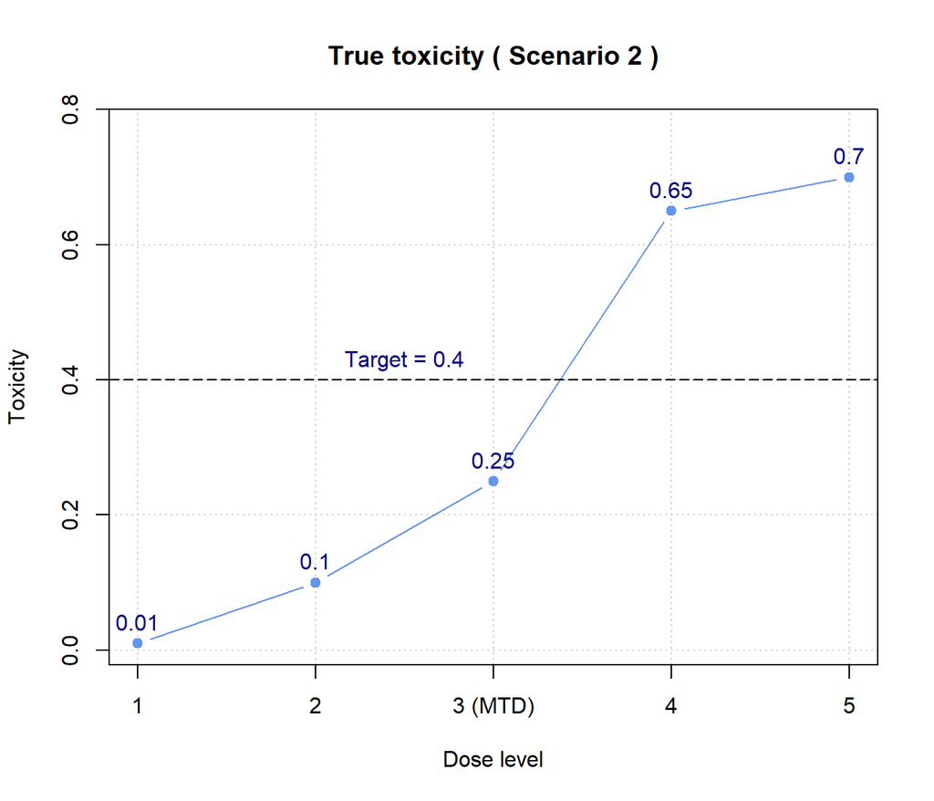

```r
# input information (true toxicity)
plot(out2, s = 2, pt = c(0.3, 0.4), type="s")
```

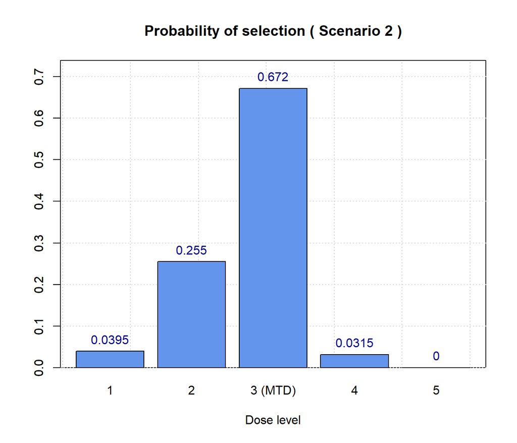

```r
# probability of selecting as MTD at each dose level
plot(out2, s = 2, pt = c(0.3, 0.4), type = "prob")
```

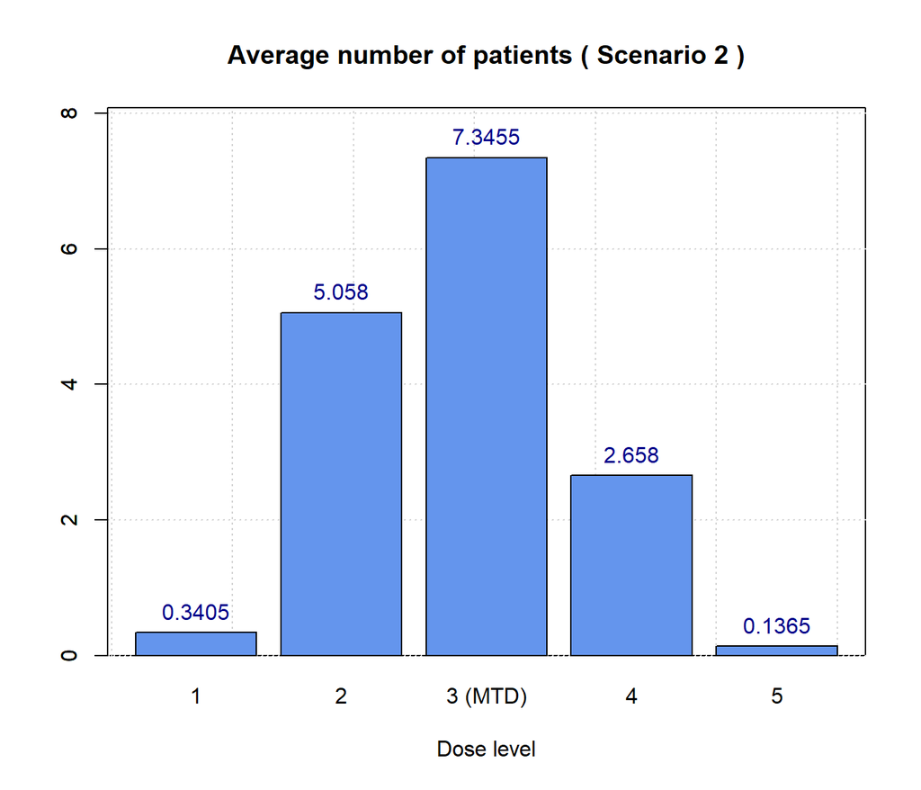

```r
# average number of patients treated at each dose level
plot(out2, s = 2, pt = c(0.3, 0.4), type = "np")
```

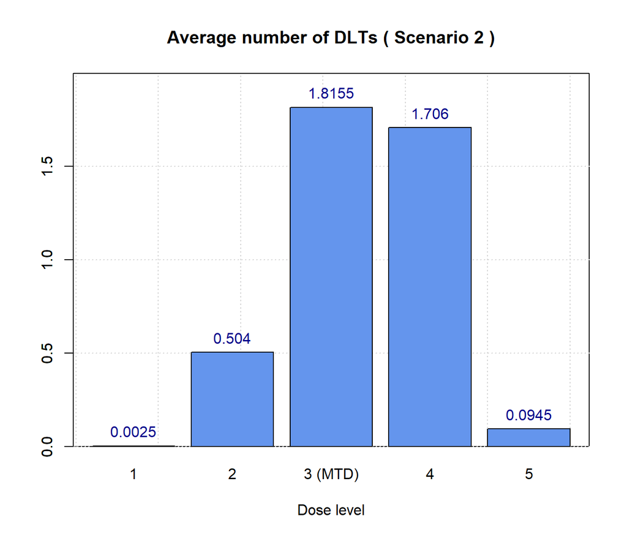

```r
# number of DLTs experienced at each dose level
plot(out2, s = 2, pt = c(0.3, 0.4), type="dlt")
```

There is a built-in function to put all different plots on same figure, simply run

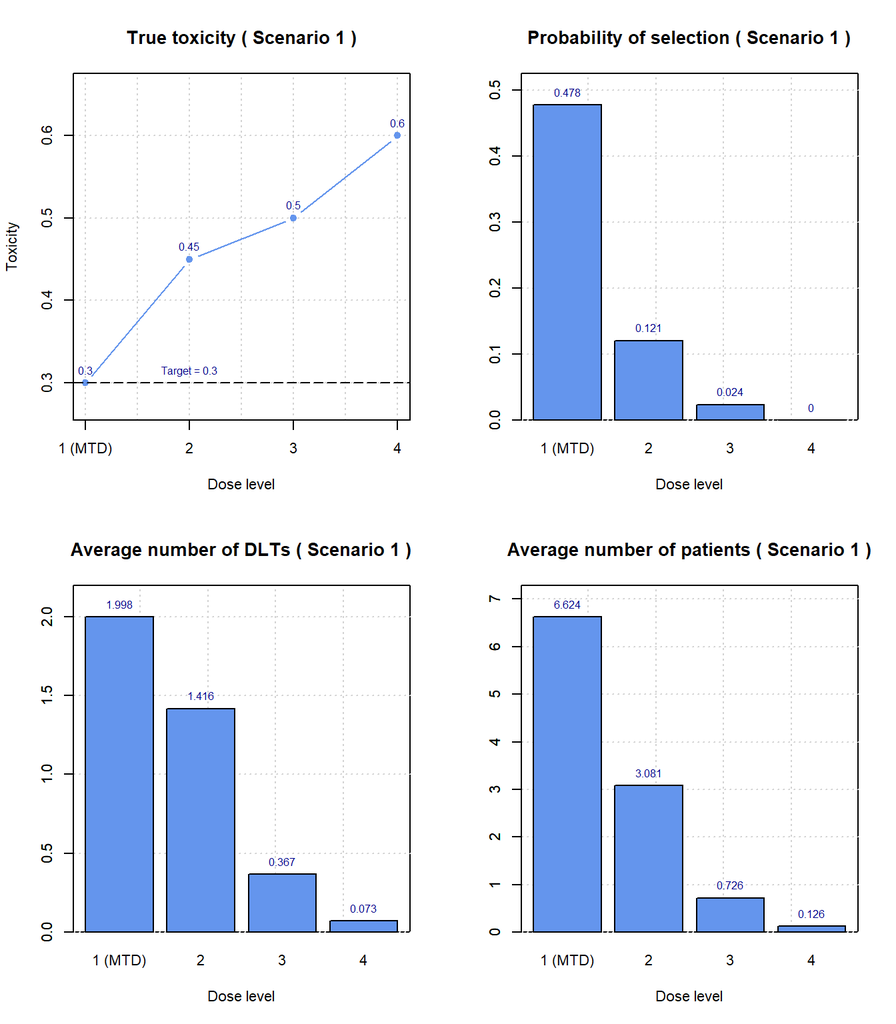

```r
plot(out2, pt = c(0.3, 0.4), type = "all", cex = 0.7)
```

## Scenarios list/customized table format

The `.csv` or `.txt` files used for `sl.sim` look like :

| Start.Dose | N.Trials | Dose1 | Dose2 | Dose3 | Dose4 | Dose5 |
| --- | --- | --- | --- | --- | --- | --- |
| 1 | 1000 | 0.30 | 0.45 | 0.50 | 0.60 | NA |
| 2 | 2000 | 0.01 | 0.10 | 0.25 | 0.65 | 0.7 |

This example is saved under `\inst\extdata\testS.csv`, use `system.file` to load it in R. The following variables have to be included: `Start.dose` : the starting dose level; `N.trails` : the number of simulated trials; `Dose*` : true probabilities of toxicity at the dose levels. Note that users don’t need put `NA` in the raw data if scenarios don’t have equal number of dose levels. In the above example, the `NA` on the first row is blank in the raw `.csv` file.

Both `dec.sim` and `sl.sim` support user-supplied decision table. It can be either `matrix`, `data.frame` or `table` in R. There is no checking on the format of the table in `tsdf`, so users need to make sure the input is a legitimate decision table for dose-finding. Also, the column name of the table should be the actual sample size instead of the default output of `read.table` which has column names `X.*` or `V.*`. For example, the following command reads the sample decision table in the package :

```r
table.file <- system.file("extdata", "decTable.csv", package = "tsdf")
dec <- read.table(table.file, sep = ",", col.names = c(3,4,8,10), row.names = 1, check.names = FALSE)
colnames(dec)
```

```
## [1] "3"  "4"  "8"  "10"
```

Although there are many ways to import a decision table from `.csv` or `.txt` files, a typical decision table used for `dev.sim` and `sl.sim` functions have to have the following format when it’s loaded in R:

|  | 3 | 4 | 8 | 10 |
| --- | --- | --- | --- | --- |
| 0 | E | E | E | E |
| 1 | S | S | E | E |
| 2 | D | D | S | E |
| 3 | DU | DU | D | S |
| 4 |  | DU | D | D |
| 5 |  |  | DU | D |
| 6 |  |  | DU | DU |
| 7 |  |  | DU | DU |
| 8 |  |  | DU | DU |
| 9 |  |  |  | DU |
| 10 |  |  |  | DU |